# Pet owners versus no-pet owners

**PetOwner**(1:Yes; 0:No) : Do you currently have or share responsibility for a pet/companion animal?

```r
# x: pet owner yes or no ('PetOwner')
# y: Kessler 1 -10, Gad 1-7, Lonely 1-3, Risk 1-3, psychproblem, and genhealth
# use ordinal logistic regression

# Kessler 1 -10:Generalized Psychological Distress
# Gad 1-7: Generalized Anxiety Disorder
# Lonely 1-3: Loneliness Short Form
# Risk 1-3: COVID Risk Perceptions
# psychproblem, and genhealth

workerid_four <- intersect(rawdatalist[[1]]$workerId,rawdatalist[[2]]$workerId)
workerid_four <- intersect(workerid_four,rawdatalist[[3]]$workerId)
workerid_four <- intersect(workerid_four,rawdatalist[[4]]$workerId)
alldata <- c()
for (d in 1:4) {

  wave <- data.frame(dplyr::select(rawdatalist[[d]],workerId,PetOwner,
                           Kessler1,Kessler2,Kessler3,Kessler4,Kessler5,
                           Kessler6,Kessler7,Kessler8,Kessler9,Kessler10,
                           Gad1,Gad2,Gad3,Gad4,Gad5,Gad6,Gad7,
                           Lonely1,Lonely2,Lonely3,
                           Risk1,Risk2,Risk3,
                           genhealth))
  timepoint <- paste0("T",d)

  wave$time <- rep(timepoint,nrow(wave))

  alldata <- rbind(alldata,wave)
}
alldata <- alldata %>%
  mutate(num=ifelse(workerId %in% workerid_four,"four","once_twice_three"))

cols <- colnames(alldata)
alldata[cols] <- lapply(alldata[cols], factor)
levels(alldata$PetOwner) <- c("No","Yes")
```

Data size:

```r
table(alldata$time)
```

```
 T1  T2  T3  T4
718 565 472 428
```

#### genhealth

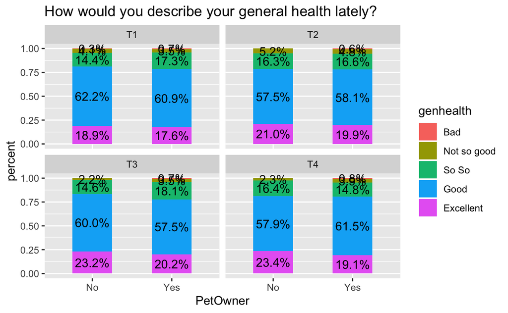

```r
sumdata1 <- alldata %>%
  group_by(time,PetOwner) %>%
  summarise(count = n())

sumdata2 <- alldata %>%
  group_by(time,PetOwner,genhealth) %>%
  summarise(percent = n())

sumdata2 <- merge(sumdata2,sumdata1,by=c("time","PetOwner"))
sumdata2$percent <- sumdata2$percent/sumdata2$count
levels(sumdata2$genhealth) <- c("Bad","Not so good",
                               "So So","Good",
                               "Excellent")

ggplot(sumdata2, aes(x=PetOwner,y=percent,fill=genhealth))+geom_col(width = 0.5)+facet_wrap(~time)+
  geom_text(aes(label = scales::percent(percent)),position = position_stack(vjust = .5))+
  ggtitle("How would you describe your general health lately?")
```

```r
m <- clmm(genhealth ~ PetOwner + time + (1|workerId), data = alldata,nAGQ = 9)
```

#### Kessler 1 -10

[output not shown]

#### Gad 1-7

```r
coef <- c()
for(q in 1:7){
  formula <- as.formula(paste0("Gad",q,"~","PetOwner + time + (1|workerId)"))
  m <- clmm(formula, data = alldata,nAGQ = 9)
  coef_q <- summary(m)$coefficients
  coef <- rbind(coef,coef_q[(nrow(coef_q)-2):nrow(coef_q),])
}
```

#### Lonely 1-3

```r
coef <- c()
for(q in 1:3){
  formula <- as.formula(paste0("Lonely",q,"~","PetOwner + time + (1|workerId)"))
  m <- clmm(formula, data = alldata,nAGQ = 9)
  coef_q <- summary(m)$coefficients
  coef <- rbind(coef,coef_q[(nrow(coef_q)-3):nrow(coef_q),])
}
```

#### Risk 1-3

```r
coef <- c()
for(q in 1:3){
  formula <- as.formula(paste0("Risk",q,"~","PetOwner + time + (1|workerId)"))
  m <- clmm(formula, data = alldata,nAGQ = 9)
  coef_q <- summary(m)$coefficients
  coef <- rbind(coef,coef_q[(nrow(coef_q)-3):nrow(coef_q),])
}
coef
```

```
                Estimate Std. Error       z value     Pr(>|z|)
PetOwnerYes  0.371918344  0.3068512   1.212047877 2.254941e-01
timeT2      -0.047793240  0.1174383  -0.406964718 6.840339e-01
timeT3      -0.441404527  0.1257630  -3.509812967 4.484220e-04
timeT4      -0.465250915  0.1317926  -3.530174859 4.152851e-04
PetOwnerYes  0.354161748  0.3152689   1.123364125 2.612829e-01
timeT2      -0.494533866  0.1280309  -3.862614047 1.121802e-04
timeT3      -0.572350015  0.1356113  -4.220518018 2.437416e-05
timeT4      -0.953996491  0.1432593  -6.659227228 2.752711e-11
PetOwnerYes  0.002956475  0.3620091   0.008166853 9.934839e-01
timeT2      -0.898235829  0.1360402  -6.602721668 4.036770e-11
timeT3      -1.459299590  0.1483726  -9.835370588 7.927520e-23
timeT4      -1.801921807  0.1566757 -11.500968956 1.304428e-30
```

## Unique questions for WAVE3 and WAVE4

```r
wave_3_4 <- c()
for (d in 3:4) {

  wave <- data.frame(dplyr::select(rawdatalist[[d]],workerId,PetOwner,
                           Aware,InfoSource,TrustInfo,
                           SusceptAnimal_1,SusceptAnimal_2,SusceptAnimal_3,SusceptAnimal_4,
                           SusceptAnimal_5,SusceptAnimal_6,SusceptAnimal_7,
                           Q92_1,Q92_2,Q92_3,Q92_4,Q92_5,Q92_6,Q92_7,Q92_8,Q92_9,
                           InfectHumans_1,InfectHumans_2,InfectHumans_3,InfectHumans_4,InfectHumans_5,
                           HumansInfectAnimal_1,HumansInfectAnimal_2,HumansInfectAnimal_3,
                           HumansInfectAnimal_4,HumansInfectAnimal_5))
  timepoint <- paste0("T",d)

  wave$time <- rep(timepoint,nrow(wave))

  wave_3_4  <- rbind(wave_3_4 ,wave)
}

cols <- colnames(wave_3_4)
wave_3_4[cols] <- lapply(wave_3_4[cols], factor)
levels(wave_3_4$PetOwner) <- c("No","Yes")
```

Data Size

```r
table(wave_3_4$PetOwner,wave_3_4$time)
```

```
       T3  T4
  No  185 171
  Yes 287 257
```

### Aware (How much have you read or heard about on the topic of COVID-19 and animals?)

- Nothing at all (1)
- A little (2)
- A moderate amount (3)
- A lot (4)
- A great deal (5)

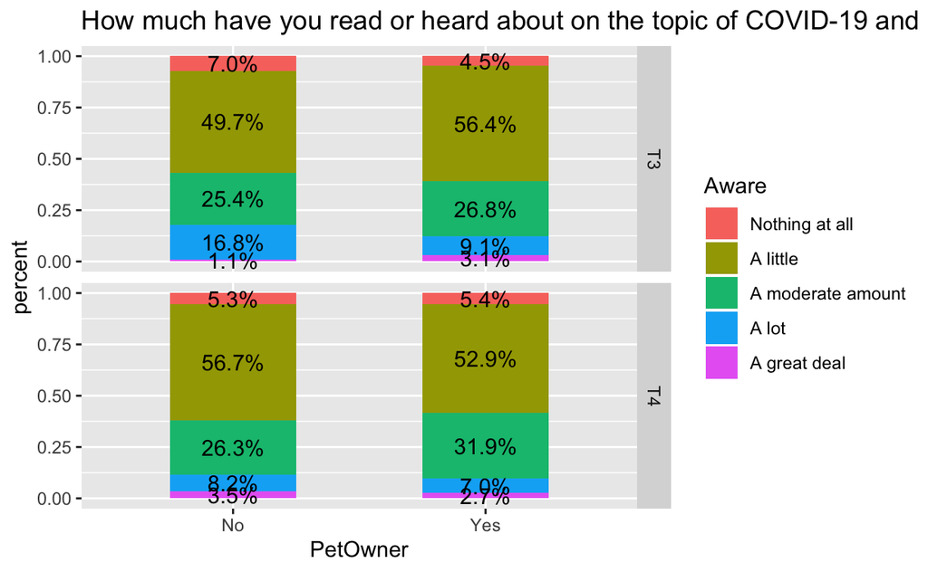

```r
m <- clmm(Aware ~ PetOwner + time + (1|workerId), data = wave_3_4, nAGQ = 9)
coef <- summary(m)$coefficients
coef[(nrow(coef)-1):nrow(coef),]
```

```
               Estimate Std. Error    z value  Pr(>|z|)
PetOwnerYes -0.04865036  0.2228109 -0.2183482 0.8271578
timeT4      -0.11521835  0.1466880 -0.7854655 0.4321807
```

### InfoSource (Which of the following options best describes where you are obtaining information about COVID-19 and animals?)

- Media/new feeds (1)
- Social media / Instagram / Facebook groups / twitter (2)
- Government and regulatory agencies (3)
- My veterinarian (4)
- Animal shelter/animal protection organization (5)
- Friends / family (6)
- Other (please describe briefly) (7)
- I do NOT have a source of information about COVID-19 and animals (8)

```r
table(wave_3_4$PetOwner,wave_3_4$InfoSource,wave_3_4$time)
```

```
, ,  = T3


        1   2   3   4   5   6   7   8
  No  111  41  10   1   0   7   1  14
  Yes 185  50  18   5   1  12   3  13

, ,  = T4


        1   2   3   4   5   6   7   8
  No  101  43   8   0   1   7   0  11
  Yes 157  45  17   6   1  14   3  14
```

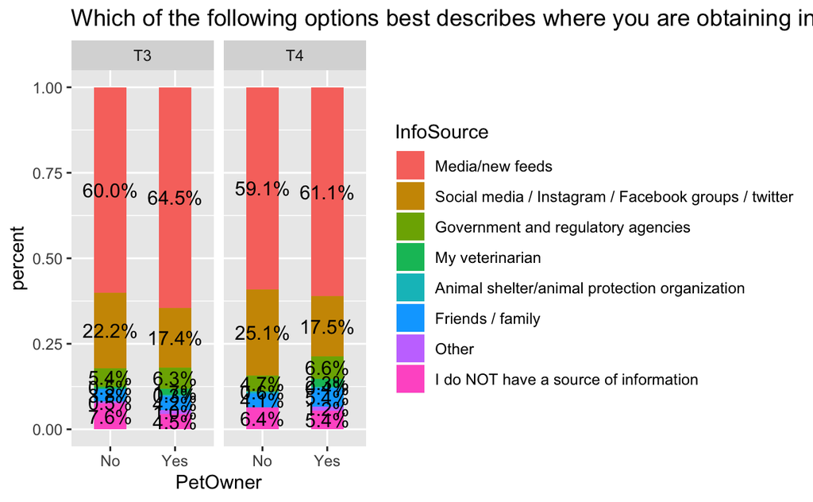

```r
sumdata1 <- wave_3_4 %>%
  group_by(time,PetOwner) %>%
  summarise(count = n())

sumdata2 <- wave_3_4 %>%
  group_by(time,PetOwner,InfoSource) %>%
  summarise(percent = n())

sumdata2 <- merge(sumdata2,sumdata1,by=c("time","PetOwner"))
sumdata2$percent <- sumdata2$percent/sumdata2$count
levels(sumdata2$InfoSource) <- c("Media/new feeds","Social media / Instagram / Facebook groups / twitter",
                               "Government and regulatory agencies","My veterinarian",
                               "Animal shelter/animal protection organization","Friends / family",
                               "Other","I do NOT have a source of information")

ggplot(sumdata2, aes(x=PetOwner,y=percent,fill=InfoSource))+geom_col(width = 0.5)+facet_grid(.~time)+
  geom_text(aes(label = scales::percent(percent)),position = position_stack(vjust = .5))+
  ggtitle("Which of the following options best describes where you are obtaining information about COVID-19 and animals?")
```

```r
cols <- c("InfoSource","PetOwner","time","workerId")
dat_temp <- wave_3_4[,cols]
m_data <- mlogit.data(data=dat_temp,
                      choice='InfoSource',
                      shape="wide",
                      id.var='workerId')

m1 <- mlogit(InfoSource ~ 0|PetOwner + time|0, data = m_data)
parNames=names(m1$coefficients)
rparArg=rep('n',length(parNames))
names(rparArg)=parNames
m <- mlogit(InfoSource ~ 0|PetOwner + time|0, data = m_data,
            panel = TRUE, rpar = rparArg[1:7])
coef <- summary(m)$coefficients
coef_mx <- matrix(coef,7,4)
colnames(coef_mx) <- c("Intercept","PetOwner","time","sd.ranef")
rownames(coef_mx) <- paste0("InfoSource",c(2:8))
coef_mx
```

[output not shown]

### TrustInfo (How trustworthy do you consider this information source to be?)

- Not at all trustworthy (1)
- Slightly trustworthy (2)
- Moderately trustworthy (3)
- Very trustworthy (4)
- Extremely trustworthy (5)

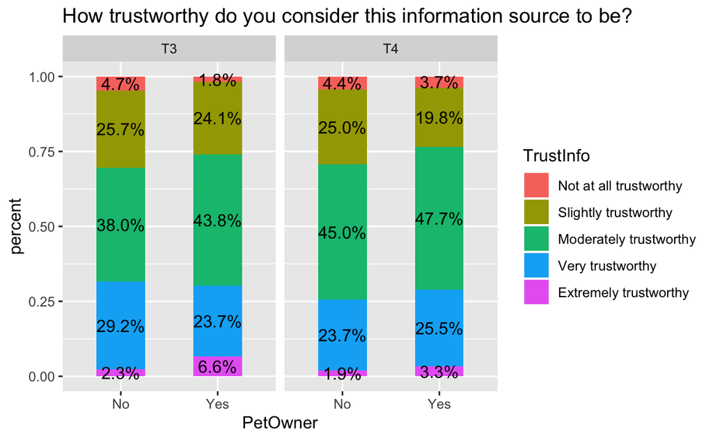

```r
m <- clmm(TrustInfo ~ PetOwner + time + (1|workerId), data = wave_3_4, nAGQ = 9)
coef <- summary(m)$coefficients
coef[(nrow(coef)-1):nrow(coef),]
```

```
              Estimate Std. Error   z value  Pr(>|z|)
PetOwnerYes  0.3395476  0.2437932  1.392769 0.1636897
timeT4      -0.1851654  0.1484611 -1.247232 0.2123124
```

### SusceptAnimal_1-7 (Based on your current knowledge, rate the extent to which you think each of the following animals can “catch” COVID-19.)

- Definitely cannot catch COVID-19 (1)
- Probably cannot catch COVID-19 (2)
- Might or might not catch COVID-19 (3)
- Probably can catch COVID-19 (4)
- Definitely can catch COVID-19 (5)

1-7 - Tigers (13) - Chimpanzees (14) - Gorillas (15) - Deer (16) - Lions (19) - Birds (20) - Bats (21)

### Q92_1-9 (Based on your current knowledge, rate the extent to which you think each of the following animals can “catch” COVID-19.)

1-9: - Dogs (13) - Cats (14) - Ferrets (15) - Rabbits (16) - Hamsters (19) - Horses (20) - Pigs (21) - Cattle (22) - Chickens (23)

```r
catch1 <- paste0("SusceptAnimal_",c(1:7))
catch2 <- paste0("Q92_",c(1:9))
cols <- c(catch1,catch2)
animals <- c("Tigers","Chimpanzees","Gorillas","Deer","Lions","Birds","Bats",
             "Dogs","Cats","Ferrets","Rabbits","Hamsters","Horses","Pigs","Cattle","Chickens")
```

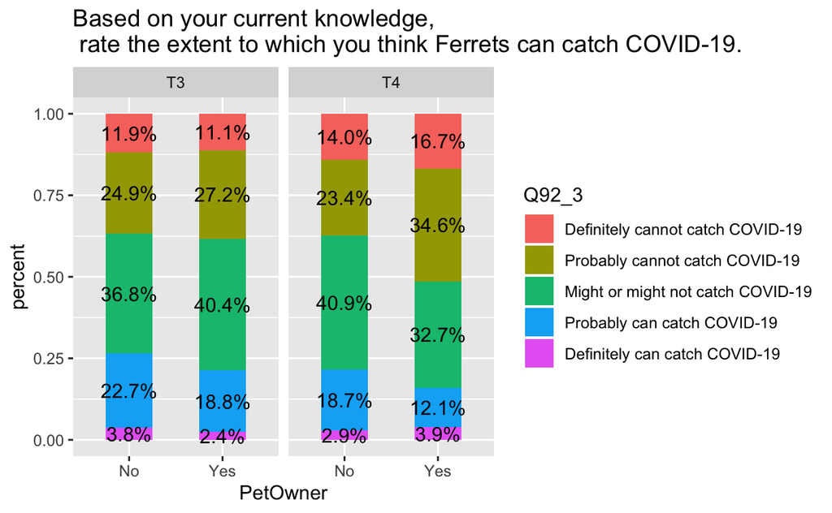

```r
sumdata1 <- wave_3_4 %>%
  group_by(time,PetOwner) %>%
  summarise(count = n())

sumdata2 <- wave_3_4 %>%
  group_by(time,PetOwner,Q92_3) %>%
  summarise(percent = n())

sumdata2 <- merge(sumdata2,sumdata1,by=c("time","PetOwner"))
sumdata2$percent <- sumdata2$percent/sumdata2$count
levels(sumdata2$Q92_3) <- c("Definitely cannot catch COVID-19","Probably cannot catch COVID-19",
                               "Might or might not catch COVID-19","Probably can catch COVID-19",
                               "Definitely can catch COVID-19")

ggplot(sumdata2, aes(x=PetOwner,y=percent,fill=Q92_3))+geom_col(width = 0.5)+facet_grid(.~time)+
  geom_text(aes(label = scales::percent(percent)),position = position_stack(vjust = .5))+
  ggtitle("Based on your current knowledge, \n rate the extent to which you think Ferrets can catch COVID-19.")
```

```r
coef <- c()
for(q in 1:length(cols)){
  formula <- as.formula(paste0(cols[q],"~","PetOwner + time + (1|workerId)"))
  m <- clmm(formula, data = wave_3_4,nAGQ = 9)
  coef_q <- summary(m)$coefficients
  coef <- rbind(coef,coef_q[(nrow(coef_q)-1):nrow(coef_q),])
}
coef
```

```
               Estimate   Std. Error      z value     Pr(>|z|)
PetOwnerYes  1.06418405 0.3298349462    3.2264139 0.0012535195
timeT4      -0.09037561 0.1489932639   -0.6065751 0.5441329047
PetOwnerYes  0.12124378 0.2697084482    0.4495365 0.6530447170
timeT4      -0.03729045 0.1447339573   -0.2576482 0.7966784100
PetOwnerYes  0.12544015 0.2463786965    0.5091355 0.6106572227
timeT4       0.03988205 0.1407641688    0.2833253 0.7769275063
PetOwnerYes -0.62572129 0.2439992299   -2.5644396 0.0103342556
timeT4      -0.24143237 0.1404404449   -1.7191085 0.0855946099
PetOwnerYes  0.87902147 0.3344911766    2.6279362 0.0085904628
timeT4      -0.04047031 0.1483180994   -0.2728616 0.7849596014
PetOwnerYes -0.34977479 0.2359908986   -1.4821537 0.1382993935
timeT4      -0.23161648 0.1389728353   -1.6666313 0.0955877332
PetOwnerYes  0.36549297 0.2657133271    1.3755161 0.1689714880
timeT4      -0.33656956 0.1477368483   -2.2781694 0.0227164881
PetOwnerYes -0.01157267 0.2861370179   -0.0404445 0.9677387532
timeT4      -0.17259763 0.1426940725   -1.2095641 0.2264461914
PetOwnerYes  0.67879262 0.3217308732    2.1098150 0.0348742948
timeT4      -0.38809748 0.1503921981   -2.5805693 0.0098637566
PetOwnerYes -0.33788246 0.2488440185   -1.3578083 0.1745245356
timeT4      -0.54026519 0.1431356363   -3.7744981 0.0001603301
PetOwnerYes -0.44673679 0.0005191136 -860.5760814 0.0000000000
timeT4      -0.37012516 0.0005025996 -736.4215427 0.0000000000
PetOwnerYes -0.45045640 0.2527114068   -1.7824933 0.0746688173
timeT4      -0.45345549 0.1426428806   -3.1789564 0.0014780633
PetOwnerYes -0.50128609 0.2583709225   -1.9401800 0.0523578213
timeT4      -0.15276948 0.1419666582   -1.0760941 0.2818851725
PetOwnerYes -0.28298503 0.2125027442   -1.3316770 0.1829663350
timeT4      -0.19110360 0.1351242607   -1.4142804 0.1572795859
PetOwnerYes -0.39114697 0.2818543631   -1.3877627 0.1652093151
timeT4      -0.22125220 0.1444235998   -1.5319671 0.1255305585
PetOwnerYes -0.69368614 0.2731277911   -2.5397860 0.0110920317
timeT4      -0.45012632 0.1454292982   -3.0951557 0.0019670960
```

### InfectHumans_1-5 (Based on your current knowledge, rate the extent to which the following animals have the ability to give COVID-19 to humans.)

- Definitely cannot give COVID-19 to humans (1)
- Probably cannot give COVID-19 to humans (2)
- Might or might give COVID-19 to humans (3)
- Probably can give COVID-19 to humans (4)
- Definitely can give COVID-19 to humans (5)

1-5: - Cats (12) - Dogs (13) - Pigs (14) - Chickens (15) - Tigers (16)

```r
animals <- c("Cats",
             "Dogs",
             "Pigs",
             "Chickens",
             "Tigers")
coef <- c()
for(q in 1:5){
  formula <- as.formula(paste0("InfectHumans_",q,"~","PetOwner + time + (1|workerId)"))
  m <- clmm(formula, data = wave_3_4,nAGQ = 9)
  coef_q <- summary(m)$coefficients
  coef <- rbind(coef,coef_q[(nrow(coef_q)-1):nrow(coef_q),])
}
coef
```

```
               Estimate Std. Error     z value    Pr(>|z|)
PetOwnerYes -0.02659775  0.2845313 -0.09347917 0.925522900
timeT4       0.16944440  0.1435949  1.18001723 0.237993362
PetOwnerYes -0.17313476  0.2721558 -0.63616053 0.524671797
timeT4       0.13479018  0.1421961  0.94791743 0.343171489
PetOwnerYes -0.55023665  0.2392758 -2.29959180 0.021471357
timeT4      -0.08951276  0.1400314 -0.63923354 0.522671013
PetOwnerYes -0.63891280  0.2429906 -2.62937281 0.008554253
timeT4      -0.13953843  0.1422635 -0.98084474 0.326669311
PetOwnerYes -0.06718119  0.2691138 -0.24963857 0.802866866
timeT4       0.14022614  0.1437255  0.97565267 0.329236615
```

### HumansInfectAnimal_1-5 (Based on your current knowledge, rate the extent to which the following animals can catch COVID-19 from humans.)

- Definitely cannot catch COVID-19 from humans (1)
- Probably cannot catch COVID-19 from humans (2)
- Might or might catch COVID-19 from humans (3)
- Probably can catch COVID-19 from humans (4)
- Definitely can catch COVID-19 from humans (5)

1-5: - Cats (12) - Dogs (13) - Pigs (14) - Chickens (15) - Tigers (16)

```r
animals <- c("Cats",
             "Dogs",
             "Pigs",
             "Chickens",
             "Tigers")

coef <- c()
for(q in 1:5){
  formula <- as.formula(paste0("HumansInfectAnimal_",q,"~","PetOwner + time + (1|workerId)"))
  m <- clmm(formula, data = wave_3_4,nAGQ = 9)
  coef_q <- summary(m)$coefficients
  coef <- rbind(coef,coef_q[(nrow(coef_q)-1):nrow(coef_q),])
}
coef
```

```
               Estimate Std. Error     z value   Pr(>|z|)
PetOwnerYes  0.32618826  0.2909492  1.12111771 0.26223776
timeT4      -0.09724932  0.1431599 -0.67930573 0.49694417
PetOwnerYes -0.14705704  0.2668974 -0.55098726 0.58164241
timeT4       0.07320525  0.1393830  0.52520931 0.59943770
PetOwnerYes -0.41293040  0.2418628 -1.70729171 0.08776785
timeT4      -0.07403065  0.1395630 -0.53044619 0.59580261
PetOwnerYes -0.62934787  0.2460579 -2.55772271 0.01053601
timeT4      -0.07029466  0.1416082 -0.49640242 0.61961052
PetOwnerYes  0.22385884  0.3171929  0.70574991 0.48034367
timeT4       0.01139935  0.1454842  0.07835457 0.93754601
```